# DATA608: Assignment 1

Eric Lehmphul

09/11/2022

```r
library(tidyverse)
```

**Principles of Data Visualization and Introduction to ggplot2**

I have provided you with data about the 5,000 fastest growing companies in the US, as compiled by Inc. magazine. lets read this in:

```r
inc <- read.csv("https://raw.githubusercontent.com/charleyferrari/CUNY_DATA_608/master/module1/Data/inc5000_data.csv", header= TRUE)
```

And lets preview this data:

```r
head(inc)
```

[output not shown]

```r
summary(inc)
```

[output not shown]

Think a bit on what these summaries mean. Use the space below to add some more relevant non-visual exploratory information you think helps you understand this data:

The default summary function does not provide the standard deviation of the numeric variables. The standard deviation can be leveraged to understand the spread of the numeric data.

```r
# Insert your code here, create more chunks as necessary

# Standard Deviations
inc %>% summarise(across(
    .cols = is.numeric,
    .fns = list(SD = sd), na.rm = TRUE,
    .names = "{col}_{fn}"
    ))
```

[output not shown]

```r
inc$Name <- as.factor(inc$Name)
inc$Industry <- as.factor(inc$Industry)
inc$City <- as.factor(inc$City)
inc$State <- as.factor(inc$State)
```

```r
get_most_least_freq <- function(variable){
  top <- inc %>%
    count({{variable}}) %>%
    arrange(desc(n)) %>%
    slice_head(n = 5)

  bottom <- inc %>%
    count({{variable}}) %>%
    arrange(desc(n)) %>%
    slice_tail(n = 5)

  return(rbind(top, bottom))
}
```

```r
get_most_least_freq(Name)
get_most_least_freq(Industry)
get_most_least_freq(City)
get_most_least_freq(State)
```

[output not shown]

After exploring the data summary information it is clear that the `Growth_Rate` column is heavily skewed as the mean is 4.612, median is 1.420, and the sd is 14.12369. There also appears to be outliers as the 3rd quartile value is 3.290 and the max is 421.480.

The variable `Employee` also has a large amount of variance. Most of the companies are relatively small in size 75% of the companies had less than 132 employees with some just having a singular worker. This data also contains much larger companies as the max value is 66,803 employees. It would be interesting to investigate whether employee size affects the growth rate of a company.

A large portion of the companies reside in large commercial cities and states. IT Services is the most popular industry by far in this dataset.

# Question 1

Create a graph that shows the distribution of companies in the dataset by State (ie how many are in each state). There are a lot of States, so consider which axis you should use. This visualization is ultimately going to be consumed on a ‘portrait’ oriented screen (ie taller than wide), which should further guide your layout choices.

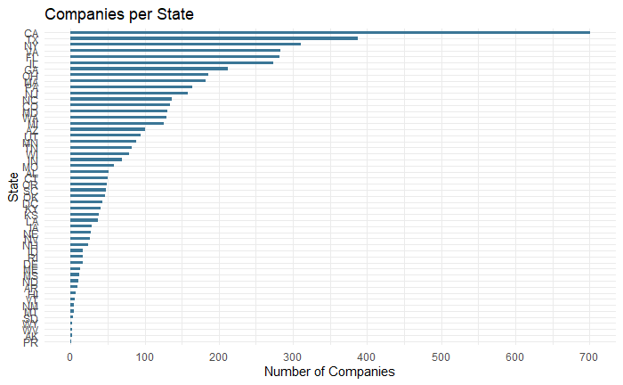

```r
# Answer Question 1 here

# Order the states in descending order
ordered.states <- inc %>% count(State)

# Create plot
ggplot(ordered.states, aes(x = reorder(State, n), y = n)) +
  geom_bar(stat = "identity", width = 0.475, position = "dodge", fill = "#3B7696") +
  ylim(0, 725) +
  scale_y_continuous(breaks = (seq(0, 700, by = 100))) +
  coord_flip() +
  ylab("Number of Companies") +
  xlab("State") +
  ggtitle("Companies per State") +
  theme_minimal()
```

# Quesiton 2

Lets dig in on the state with the 3rd most companies in the data set. Imagine you work for the state and are interested in how many people are employed by companies in different industries. Create a plot that shows the average and/or median employment by industry for companies in this state (only use cases with full data, use R’s `complete.cases()` function.) In addition to this, your graph should show how variable the ranges are, and you should deal with outliers.

## Using Barplots

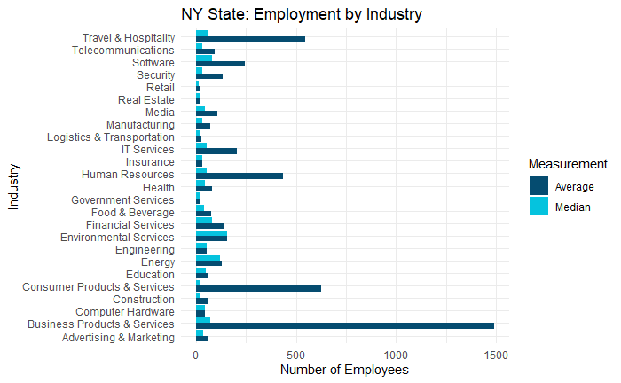

```r
# Answer Question 2 here

# Get data for the state with the 3r most companies (NY)
q2.data.barplot <- inc %>%
  filter(State == "NY") %>%
  filter(complete.cases(.)) %>%
  group_by(Industry) %>%
  summarise(Average = mean(Employees), Median = median(Employees)) %>%
  gather("Measurement", "value", 2:3)

# Create Plot
q2.data.barplot %>% ggplot(aes(x = Industry, y = value)) +
  geom_bar(stat = "identity", position = position_dodge(), aes(fill=Measurement)) +
  coord_flip() +
  xlab("Industry") +
  ylab("Number of Employees") +
  ggtitle("NY State: Employment by Industry") +
  scale_fill_manual(values = c("#054C70","#05C3DE")) +
  theme_minimal()
```

```r
NA
NA
```

## Using Boxplots

### With all Outliers

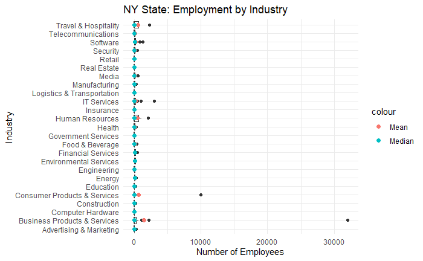

```r
q2.data <- inc %>%
  filter(State == "NY") %>%
  filter(complete.cases(.))

# Create plot
q2.data %>% ggplot(aes(x = Employees, y = Industry)) +
  geom_boxplot() +
  stat_summary(fun = "mean", size = 2, geom = "point", aes(color = "Mean")) +
  stat_summary(fun = "median", size = 2, geom = "point", aes(color = "Median")) +
  ggtitle("NY State: Employment by Industry") +
  xlab("Number of Employees") +
  theme_minimal()
```

### Excluded Outliers

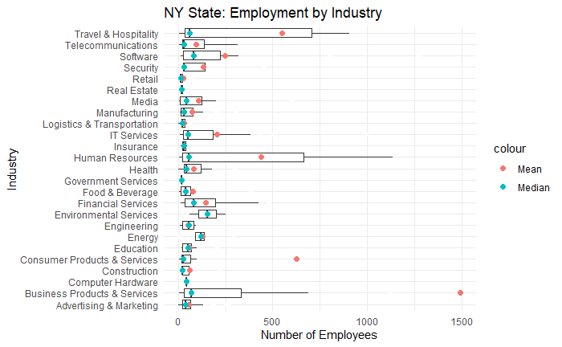

```r
q2.data %>% ggplot(aes(x = Industry, y = Employees)) +
  geom_boxplot(outlier.color = "white") +
  coord_flip(ylim = c(0, 1500)) +
  stat_summary(fun = "mean", size = 2, geom = "point", aes(color = "Mean")) +
  stat_summary(fun = "median", size = 2, geom = "point", aes(color = "Median")) +
  ggtitle("NY State: Employment by Industry") +
  ylab("Number of Employees") +
  theme_minimal()
```

# Question 3

Now imagine you work for an investor and want to see which industries generate the most revenue per employee. Create a chart that makes this information clear. Once again, the distribution per industry should be shown.

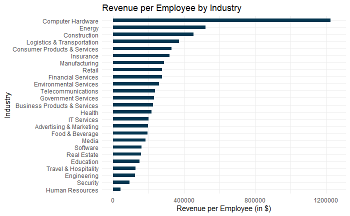

```r
# Answer Question 3 here

# remove scientific notation
options(scipen = 5)

# Generate the revenue per employee
revenue.data <- inc %>%
  filter(complete.cases(.)) %>%
  group_by(Industry) %>%
  summarise(total_revenue = sum(Revenue), total_employees = sum(Employees), revenue_per_employee = (total_revenue / total_employees))

# Create plot

revenue.data %>% ggplot(aes(x = revenue_per_employee, y = reorder(Industry, revenue_per_employee))) +
  geom_bar(stat = "identity", width = 0.475, position = "dodge", fill = "#04354F") +
  xlab("Revenue per Employee (in $)") +
  ylab("Industry") +
  xlim(0, 1250000) +
  ggtitle("Revenue per Employee by Industry") +
  theme_minimal()
```